# Amazon Reviews Classification

Naveen Kaveti

6/28/2020

### Problem Statement:

Amazon classifies product reviews into positive and critical for better user experience in the product.

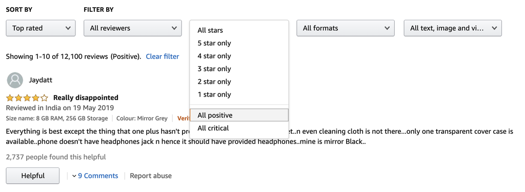

### Data:

```r
df <- fread('./amazonreviews.tsv')
head(df) %>%
  kable() %>%
  kable_styling()
```

| label | review |
| --- | --- |
| pos | Stuning even for the non-gamer: This sound track was beautiful! It paints the senery in your mind so well I would recomend it even to people who hate vid. game music! I have played the game Chrono Cro… |
| pos | The best soundtrack ever to anything.: I'm reading a lot of reviews saying that this is the best 'game soundtrack' and I figured that I'd write a review to disagree a bit. This in my opinino is Yasuno… |
| pos | Amazing!: This soundtrack is my favorite music of all time, hands down. The intense sadness of ""Prisoners of Fate"" (which means all the more if you've played the game) and the hope in ""A Distant Pr… |
| pos | Excellent Soundtrack: I truly like this soundtrack and I enjoy video game music. I have played this game and most of the music on here I enjoy and it's truly relaxing and peaceful.On disk one. my favo… |
| pos | Remember, Pull Your Jaw Off The Floor After Hearing it: If you've played the game, you know how divine the music is! Every single song tells a story of the game, it's that good! The greatest songs are… |
| pos | an absolute masterpiece: I am quite sure any of you actually taking the time to read this have played the game at least once, and heard at least a few of the tracks here. And whether you were aware of… |

**Statistics:**

Number of total reviews: 10000

Number of positive reviews: 4903 (49.03%)

Number of negative reviews: 5097 (50.97%)

```r
# Converting label to binary (1: Positive; 0: Negative)
df$label <- ifelse(df$label == 'pos', 1, 0)
```

### Text preprocessing

**Step 1:** Removing special characters and trimming extra white spaces

```r
Stuning even for the non-gamer: This sound track was beautiful! It paints the senery in your mind so well I would recomend it even to people who hate vid. game music! I have played the game Chrono Cross but out of all of the games I have ever played it has the best music! It backs away from crude keyboarding and takes a fresher step with grate guitars and soulful orchestras. It would impress anyone who cares to listen! ^_^
```

```r
review <- df$review[1]
review_cleaned <- trimws(str_replace_all(review, "[^[:alnum:]]", " "))
review_cleaned <- gsub("\\s+", " ", str_trim(review_cleaned))
print(review_cleaned)
```

```
[1] "Stuning even for the non gamer This sound track was beautiful It paints the senery in your mind so well I would recomend it even to people who hate vid game music I have played the game Chrono Cross but out of all of the games I have ever played it has the best music It backs away from crude ke…
```

Regular expressions are useful to search patterns in the text. Refer [this](https://stat.ethz.ch/R-manual/R-devel/library/base/html/regex.html#:~:text=A%20'regular%20expression'%20is%20a,use%20a%20literal%20regular%20expression.) document for more information.

**Step 2:** Removing stop words

```r
stopwords('en')
```

```
  [1] "i"          "me"         "my"         "myself"     "we"
  [6] "our"        "ours"       "ourselves"  "you"        "your"
 [11] "yours"      "yourself"   "yourselves" "he"         "him"
 [16] "his"        "himself"    "she"        "her"        "hers"
 [21] "herself"    "it"         "its"        "itself"     "they"
 [26] "them"       "their"      "theirs"     "themselves" "what"
 [31] "which"      "who"        "whom"       "this"       "that"
 [36] "these"      "those"      "am"         "is"         "are"
 [41] "was"        "were"       "be"         "been"       "being"
 [46] "have"       "has"        "had"        "having"     "do"
 [51] "does"       "did"        "doing"      "would"      "should"
 [56] "could"      "ought"      "i'm"        "you're"     "he's"
 [61] "she's"      "it's"       "we're"      "they're"    "i've"
 [66] "you've"     "we've"      "they've"    "i'd"        "you'd"
 [71] "he'd"       "she'd"      "we'd"       "they'd"     "i'll"
```

[output cut: 20 more lines]

```r
stopwords_regex = paste(stopwords('en'), collapse = '\\b|\\b')
stopwords_regex = paste0('\\b', stopwords_regex, '\\b')

review_cleaned_without_stopwords <- tolower(review_cleaned)
review_cleaned_without_stopwords <- str_replace_all(review_cleaned_without_stopwords, stopwords_regex, '')
review_cleaned_without_stopwords <- gsub("\\s+", " ", str_trim(review_cleaned_without_stopwords))
print(review_cleaned_without_stopwords)
```

```
[1] "stuning even non gamer sound track beautiful paints senery mind well recomend even people hate vid game music played game chrono cross games ever played best music backs away crude keyboarding takes fresher step grate guitars soulful orchestras impress anyone cares listen"
```

**Step 3:** Stemming and Lemmatization

```r
spacy_initialize()
parsedtxt <- spacy_parse(review_cleaned_without_stopwords, entity = FALSE)
parsedtxt %>%
  kable() %>%
  kable_styling() %>%
  scroll_box(width = "100%", height = "400px")
```

| doc_id | sentence_id | token_id | token | lemma | pos |
| --- | --- | --- | --- | --- | --- |
| text1 | 1 | 1 | stuning | stuning | NOUN |
| text1 | 1 | 2 | even | even | ADV |
| text1 | 1 | 3 | non | non | ADJ |
| text1 | 1 | 4 | gamer | gamer | ADJ |
| text1 | 1 | 5 | sound | sound | ADJ |
| text1 | 1 | 6 | track | track | NOUN |
| text1 | 1 | 7 | beautiful | beautiful | ADJ |
| text1 | 1 | 8 | paints | paint | NOUN |
| text1 | 1 | 9 | senery | senery | VERB |
| text1 | 1 | 10 | mind | mind | NOUN |
| text1 | 2 | 1 | well | well | INTJ |
| text1 | 2 | 2 | recomend | recomend | VERB |
| text1 | 2 | 3 | even | even | ADV |
| text1 | 2 | 4 | people | people | NOUN |
| text1 | 2 | 5 | hate | hate | VERB |
| text1 | 2 | 6 | vid | vid | PROPN |
| text1 | 2 | 7 | game | game | PROPN |
| text1 | 2 | 8 | music | music | NOUN |
| text1 | 2 | 9 | played | play | VERB |
| text1 | 3 | 1 | game | game | NOUN |
| text1 | 3 | 2 | chrono | chrono | PROPN |
| text1 | 3 | 3 | cross | cross | PROPN |
| text1 | 3 | 4 | games | game | NOUN |
| text1 | 3 | 5 | ever | ever | ADV |
| text1 | 3 | 6 | played | play | VERB |
| text1 | 3 | 7 | best | good | ADJ |
| text1 | 3 | 8 | music | music | NOUN |
| text1 | 3 | 9 | backs | back | NOUN |
| text1 | 3 | 10 | away | away | ADV |
| text1 | 3 | 11 | crude | crude | ADJ |
| text1 | 3 | 12 | keyboarding | keyboarding | NOUN |
| text1 | 3 | 13 | takes | take | VERB |
| text1 | 3 | 14 | fresher | fresh | ADJ |
| text1 | 3 | 15 | step | step | NOUN |
| text1 | 3 | 16 | grate | grate | VERB |
| text1 | 3 | 17 | guitars | guitar | VERB |
| text1 | 4 | 1 | soulful | soulful | ADJ |
| text1 | 4 | 2 | orchestras | orchestra | NOUN |
| text1 | 4 | 3 | impress | impress | VERB |
| text1 | 4 | 4 | anyone | anyone | PRON |
| text1 | 4 | 5 | cares | care | NOUN |
| text1 | 4 | 6 | listen | listen | VERB |

Refer [this](https://www.rdocumentation.org/packages/spacyr/versions/0.9.91) document for more information about Spacy

Stemming and Lemmatizations are two techniques used for normalizing text. The major difference between stemming and lemmatization is, stemming do not check for english vocabulary while lemmatization checks for english vocabulary.

**Step 4:** Extracting entities

```r
parsedtxt_ent <- spacy_parse(review_cleaned, lemma = FALSE)
entity_extract(parsedtxt_ent) %>%
  kable() %>%
  kable_styling()
```

| doc_id | sentence_id | entity | entity_type |
| --- | --- | --- | --- |
| text1 | 6 | Chrono_Cross | ORG |

### Preprocessing on entire data

```r
# Preprocessing entire corpus
df[, review_processed := str_replace_all(review, "[^[:alnum:]]", " ")]
df[, review_processed := tolower(review_processed)]
df[, review_processed := str_replace_all(review_processed, stopwords_regex, '')]
df[, review_processed := gsub("\\s+", " ", str_trim(review_processed))]
```

### Feature extraction

#### Count vectorizer:

$$Tf(w, d) = Number \ of \ times \ word \ `w` \ appears \ in \ document \ `d`$$

```r
# initialise the class
countVec <- CountVectorizer$new(max_features = 100, remove_stopwords = FALSE, min_df = 0.2, max_df = 0.8)

# generate the matrix
countVecMat <- countVec$fit_transform(df$review_processed)
countVecMat <- data.table(countVecMat)
countVecMat$label <- df$label

head(countVecMat, 10) %>%
  kable() %>%
  kable_styling() %>%
  scroll_box(width = "100%", height = "400px")
```

| book | s | t | one | like | good | read | great | movie | just | can | time | get | don | really | well | first | much | even | story | buy | love | better | best | m | books | also | work | product | think | … |
| --- | --- | --- | --- | --- | --- | --- | --- | --- | --- | --- | --- | --- | --- | --- | --- | --- | --- | --- | --- | --- | --- | --- | --- | --- | --- | --- | --- | --- | --- | --- |
| 0 | 0 | 0 | 0 | 0 | 0 | 0 | 0 | 0 | 0 | 0 | 0 | 0 | 0 | 0 | 1 | 0 | 0 | 2 | 0 | 0 | 0 | 0 | 1 | 0 | 0 | 0 | 0 | 0 | 0 | … |
| 0 | 1 | 0 | 1 | 0 | 0 | 0 | 0 | 0 | 0 | 0 | 0 | 0 | 0 | 0 | 0 | 0 | 1 | 0 | 0 | 1 | 0 | 0 | 2 | 2 | 0 | 0 | 0 | 0 | 0 | … |
| 0 | 2 | 2 | 0 | 1 | 0 | 0 | 0 | 0 | 0 | 1 | 3 | 0 | 0 | 0 | 1 | 0 | 0 | 1 | 0 | 1 | 0 | 0 | 1 | 0 | 0 | 0 | 1 | 0 | 0 | … |
| 0 | 2 | 0 | 1 | 2 | 0 | 0 | 0 | 0 | 0 | 0 | 1 | 0 | 0 | 0 | 0 | 0 | 0 | 0 | 0 | 0 | 0 | 0 | 1 | 0 | 0 | 0 | 0 | 0 | 0 | … |
| 0 | 2 | 0 | 0 | 0 | 1 | 0 | 0 | 0 | 1 | 1 | 1 | 0 | 0 | 0 | 0 | 0 | 0 | 0 | 1 | 0 | 0 | 0 | 1 | 0 | 0 | 0 | 0 | 0 | 0 | … |
| 0 | 3 | 1 | 2 | 0 | 0 | 1 | 0 | 0 | 0 | 0 | 2 | 0 | 0 | 0 | 0 | 0 | 0 | 1 | 0 | 0 | 0 | 0 | 2 | 0 | 0 | 0 | 0 | 0 | 0 | … |
| 5 | 1 | 2 | 2 | 0 | 0 | 1 | 0 | 0 | 0 | 3 | 0 | 0 | 0 | 0 | 0 | 0 | 0 | 1 | 0 | 0 | 0 | 0 | 0 | 0 | 0 | 0 | 0 | 0 | 0 | … |
| 4 | 0 | 0 | 0 | 0 | 0 | 1 | 0 | 0 | 0 | 0 | 0 | 0 | 0 | 0 | 0 | 0 | 1 | 0 | 4 | 0 | 0 | 0 | 0 | 0 | 0 | 0 | 0 | 0 | 0 | … |
| 2 | 1 | 1 | 1 | 0 | 0 | 2 | 0 | 0 | 3 | 0 | 1 | 0 | 1 | 0 | 0 | 0 | 0 | 0 | 0 | 0 | 1 | 0 | 0 | 0 | 1 | 0 | 0 | 0 | 0 | … |
| 2 | 0 | 0 | 0 | 0 | 0 | 4 | 0 | 0 | 0 | 0 | 0 | 0 | 0 | 0 | 0 | 0 | 0 | 0 | 0 | 0 | 0 | 0 | 0 | 0 | 0 | 0 | 0 | 0 | 0 | … |

Where each cell represents number of times word `w` appears in document `d`.

#### TF-IDF (Term Frequency - Inverse Document Frequency):

The main drawback of count vectorizer is, it is biased to high frequent words. Meaning, if a word is high frequenct then count vectorizer gives high importance to those words but in real word scenrio it might not be true. So inverse document frequency penalizes when term frequency is very high.

$$Tf(w, d) = Number \ of \ times \ word \ `w` \ appears \ in \ document \ `d`$$

$$IDF(w) = \log \frac{Total \ number \ of \ documents}{Number \ of \ documents \ with \ word \ `w`}$$

$$Tfidf(w, d) = Tf(w, d) * IDF(w)$$

```r
# initialise the class
tfidfVec <- TfIdfVectorizer$new(max_features = 100, remove_stopwords = FALSE, min_df = 0.2, max_df = 0.8, ngram_range = c(1, 3))

# generate the matrix
tfidfVecMat <- tfidfVec$fit_transform(df$review_processed)
tfidfVecMat <- data.table(tfidfVecMat)
tfidfVecMat$label <- df$label

head(tfidfVecMat, 10) %>%
  kable() %>%
  kable_styling() %>%
  scroll_box(width = "100%", height = "400px")
```

| book | s | t | one | like | good | read | great | movie | just | can | time | get | don | don t | really | well | first | much | even | story | buy | love | better | best | m | books | also | work | product | … |
| --- | --- | --- | --- | --- | --- | --- | --- | --- | --- | --- | --- | --- | --- | --- | --- | --- | --- | --- | --- | --- | --- | --- | --- | --- | --- | --- | --- | --- | --- | --- |
| 0.0000000 | 0.0000000 | 0.0000000 | 0.0000000 | 0.0000000 | 0.0000000 | 0.0000000 | 0 | 0 | 0.0000000 | 0.0000000 | 0.0000000 | 0 | 0.0000000 | 0.000000 | 0 | 0.1971553 | 0 | 0.0000000 | 0.3981868 | 0.0000000 | 0.0000000 | 0.0000000 | 0 | 0.2167912 | 0.0000000 | 0.0000000 | 0 | 0.0000000 | 0 | … |
| 0.0000000 | 0.1119837 | 0.0000000 | 0.1236085 | 0.0000000 | 0.0000000 | 0.0000000 | 0 | 0 | 0.0000000 | 0.0000000 | 0.0000000 | 0 | 0.0000000 | 0.000000 | 0 | 0.0000000 | 0 | 0.1704570 | 0.0000000 | 0.0000000 | 0.1788567 | 0.0000000 | 0 | 0.3714115 | 0.3807791 | 0.0000000 | 0 | 0.0000000 | 0 | … |
| 0.0000000 | 0.1916310 | 0.1910793 | 0.0000000 | 0.1187942 | 0.0000000 | 0.0000000 | 0 | 0 | 0.0000000 | 0.1259665 | 0.3967223 | 0 | 0.0000000 | 0.000000 | 0 | 0.1445017 | 0 | 0.0000000 | 0.1459222 | 0.0000000 | 0.1530334 | 0.0000000 | 0 | 0.1588935 | 0.0000000 | 0.0000000 | 0 | 0.1650112 | 0 | … |
| 0.0000000 | 0.1999352 | 0.0000000 | 0.1103450 | 0.2478842 | 0.0000000 | 0.0000000 | 0 | 0 | 0.0000000 | 0.0000000 | 0.1379713 | 0 | 0.0000000 | 0.000000 | 0 | 0.0000000 | 0 | 0.0000000 | 0.0000000 | 0.0000000 | 0.0000000 | 0.0000000 | 0 | 0.1657791 | 0.0000000 | 0.0000000 | 0 | 0.0000000 | 0 | … |
| 0.0000000 | 0.2575323 | 0.0000000 | 0.0000000 | 0.0000000 | 0.1606034 | 0.0000000 | 0 | 0 | 0.1642689 | 0.1692860 | 0.1777180 | 0 | 0.0000000 | 0.000000 | 0 | 0.0000000 | 0 | 0.0000000 | 0.0000000 | 0.2080153 | 0.0000000 | 0.0000000 | 0 | 0.2135365 | 0.0000000 | 0.0000000 | 0 | 0.0000000 | 0 | … |
| 0.0000000 | 0.3299010 | 0.1096504 | 0.2427648 | 0.0000000 | 0.0000000 | 0.1464021 | 0 | 0 | 0.0000000 | 0.0000000 | 0.3035442 | 0 | 0.0000000 | 0.000000 | 0 | 0.0000000 | 0 | 0.0000000 | 0.1674743 | 0.0000000 | 0.0000000 | 0.0000000 | 0 | 0.3647227 | 0.0000000 | 0.0000000 | 0 | 0.0000000 | 0 | … |
| 0.4705774 | 0.0870945 | 0.1736875 | 0.1922712 | 0.0000000 | 0.0000000 | 0.1159513 | 0 | 0 | 0.0000000 | 0.3435037 | 0.0000000 | 0 | 0.0000000 | 0.000000 | 0 | 0.0000000 | 0 | 0.0000000 | 0.1326406 | 0.0000000 | 0.0000000 | 0.0000000 | 0 | 0.0000000 | 0.0000000 | 0.0000000 | 0 | 0.0000000 | 0 | … |
| 0.4996307 | 0.0000000 | 0.0000000 | 0.0000000 | 0.0000000 | 0.0000000 | 0.1538876 | 0 | 0 | 0.0000000 | 0.0000000 | 0.0000000 | 0 | 0.0000000 | 0.000000 | 0 | 0.0000000 | 0 | 0.1759458 | 0.0000000 | 0.7469172 | 0.0000000 | 0.0000000 | 0 | 0.0000000 | 0.0000000 | 0.0000000 | 0 | 0.0000000 | 0 | … |
| 0.2901738 | 0.1342635 | 0.1338769 | 0.1482010 | 0.0000000 | 0.0000000 | 0.3574973 | 0 | 0 | 0.5138456 | 0.0000000 | 0.1853052 | 0 | 0.1967073 | 0.197182 | 0 | 0.0000000 | 0 | 0.0000000 | 0.0000000 | 0.0000000 | 0.0000000 | 0.2205875 | 0 | 0.0000000 | 0.0000000 | 0.2393411 | 0 | 0.0000000 | 0 | … |
| 0.2528137 | 0.0000000 | 0.0000000 | 0.0000000 | 0.0000000 | 0.0000000 | 0.6229387 | 0 | 0 | 0.0000000 | 0.0000000 | 0.0000000 | 0 | 0.0000000 | 0.000000 | 0 | 0.0000000 | 0 | 0.0000000 | 0.0000000 | 0.0000000 | 0.0000000 | 0.0000000 | 0 | 0.0000000 | 0.0000000 | 0.0000000 | 0 | 0.0000000 | 0 | … |

**ngram_range:** c(1, 3), this will consider all uni, bi and tri grams tfidf metrics. uni-gram is one word, bi-gram is consecutive two words and tri-gram is consecutive three words. Importance of this feature is, if a user writes `product is not good` or `product is not that bad` and if we consider each word individually then our model will get confused. So in such cases we should consider bi or tri grams to get the context around the word.

#### Word2Vec:

```r
# Creating word index for the review vocabulary
GLOVE_DIR <- 'glove.6B'
EMBEDDING_DIM <- 100
texts <- df$review_processed
tokenizer <- text_tokenizer(num_words=100000)
tokenizer %>% fit_text_tokenizer(texts)
save_text_tokenizer(tokenizer, "tokenizer")
sequences <- texts_to_sequences(tokenizer, texts)
word_index <- tokenizer$word_index

# Creating embedding index with 100-dimensional values
embeddings_index <- new.env(parent = emptyenv())
lines <- readLines(file.path(GLOVE_DIR, 'glove.6B.100d.txt'))
for (line in lines) {
  values <- strsplit(line, ' ', fixed = TRUE)[[1]]
  word <- values[[1]]
  coefs <- as.numeric(values[-1])
  embeddings_index[[word]] <- coefs
}

# prepare embedding matrix
num_words <- length(word_index)
prepare_embedding_matrix <- function() {
  embedding_matrix <- matrix(0L, nrow = num_words, ncol = EMBEDDING_DIM)
  for(word in names(word_index)){
    index <- word_index[[word]]
    embedding_vector <- embeddings_index[[word]]
    if(!is.null(embedding_vector)){
      # words not found in embedding index will be all-zeros.
      embedding_matrix[index,] <- embedding_vector
    }
  }
  embedding_matrix
}
```

```r
embedding_matrix <- fread('embedding_matrix.csv')
row_names <- embedding_matrix$row_names
embedding_matrix$row_names <- NULL
embedding_matrix <- as.matrix(embedding_matrix)
row.names(embedding_matrix) <- row_names

# Function to identify similar words for a given word
find_similar_words <- function(word, n = 5){
  similarities <- embedding_matrix[word, , drop = FALSE] %>%
    sim2(embedding_matrix, y = ., method = "cosine")

  similarities[,1] %>% sort(decreasing = TRUE) %>% head(n)
}
```

So far we learned how to extract features from text data using term frequencies and inverse document frequencies but in either of these cases we are not considering semantics of words. Researchers trained deep learning models to provide mathematical descriptions of individual words such that words that appear frequently together in the language will have similar values.

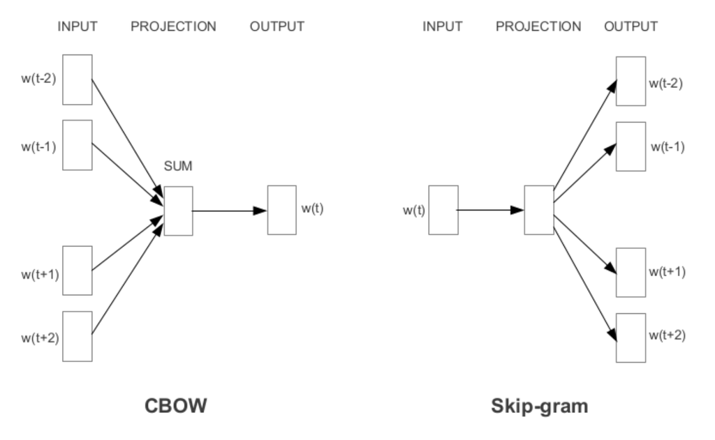

CBOW (Continuous Bag Of Words) and Skip-gram are two famous training frameworks to train the word2vec model.

CBOW takes context around the word as input and predicts the word, whereas skip-gram takes an individual word as input and predicts context around that word.

**Few examples:**

```r
find_similar_words("king")
```

```
     king    prince     queen       son   brother
1.0000000 0.7682329 0.7507691 0.7020888 0.6985776
```

```r
find_similar_words("good")
```

```
     good    better      sure    really      kind
1.0000000 0.8931914 0.8314563 0.8297762 0.8288268
```

```r
find_similar_words("bad")
```

```
      bad     worse      good    things     thing
1.0000000 0.7929713 0.7702798 0.7653603 0.7609668
```

```r
find_similar_words("learning")
```

```
  learning   teaching  knowledge experience     skills
 1.0000000  0.7720069  0.7606413  0.7378624  0.7343751
```

```r
find_similar_words("product")
```

```
     product     products        sales distribution        brand
   1.0000000    0.8239001    0.7630949    0.7073397    0.6989934
```

**Preparing word embeddings for review data:**

```r
load('sequences.RData')
word_embeddings_df <- data.table(do.call('rbind', lapply(sequences, function(x){colMeans(embedding_matrix[x, ])})))
word_embeddings_df$label <- df$label
```

### Training a binary classifier

```r
get_classifier <- function(df){
  response <- 'label'
  predictors <- setdiff(colnames(df), response)

  set.seed(123)
  train_ind = sample(seq_len(nrow(df)),size = round(nrow(df)*0.7))

  train <- df[train_ind, ]
  test <- df[-train_ind, ]

  train_h2o <- as.h2o(train)
  test_h2o <- as.h2o(test)

  rf_model <- h2o.randomForest(x = predictors, y = response, training_frame = train_h2o, nfolds = 5, seed = 1234)
  test$pred_prob <- as.data.frame.array(predict(rf_model, test_h2o))
  test$pred_label <- 1
  test$pred_label[test$pred_prob < 0.5] = 0

  test$label <- as.factor(test$label)
  test$pred_label <- as.factor(test$pred_label)

  cm <- conf_mat(test, 'label', 'pred_label')
  g_plot <- autoplot(cm, type = "heatmap") + scale_fill_gradient(low="#D6EAF8",high = "#2E86C1")

  accuracy <- round((sum(diag(cm$table))/sum(cm$table))*100, 2)
  print(paste0("Accuracy (Number of correct classifications/Total number of cases): ", accuracy, "%"))

  return(list(test[, .(label, pred_label)], g_plot))
}
```

#### Using Count Vectorizer

```r
results_cv <- get_classifier(countVecMat)
```

```
[1] "Accuracy (Number of correct classifications/Total number of cases): 71.37%"
```

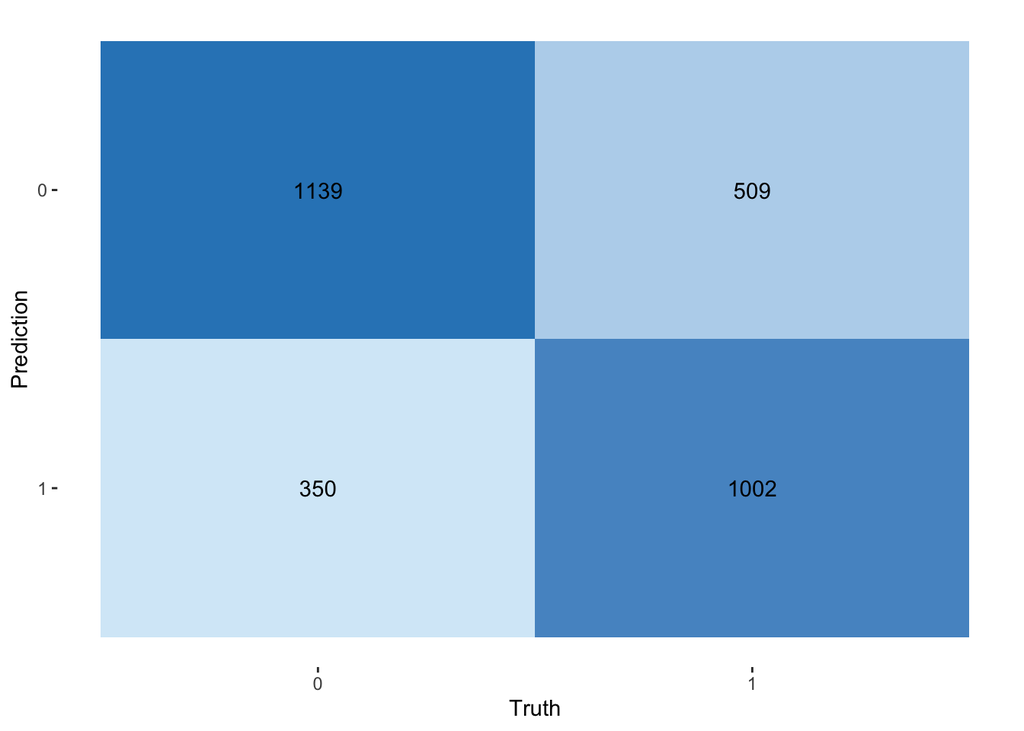

```r
results_cv[[2]]
```

#### Using Tfidf Vectorizer

```r
results_tfidf <- get_classifier(tfidfVecMat)
```

```
[1] "Accuracy (Number of correct classifications/Total number of cases): 71.97%"
```

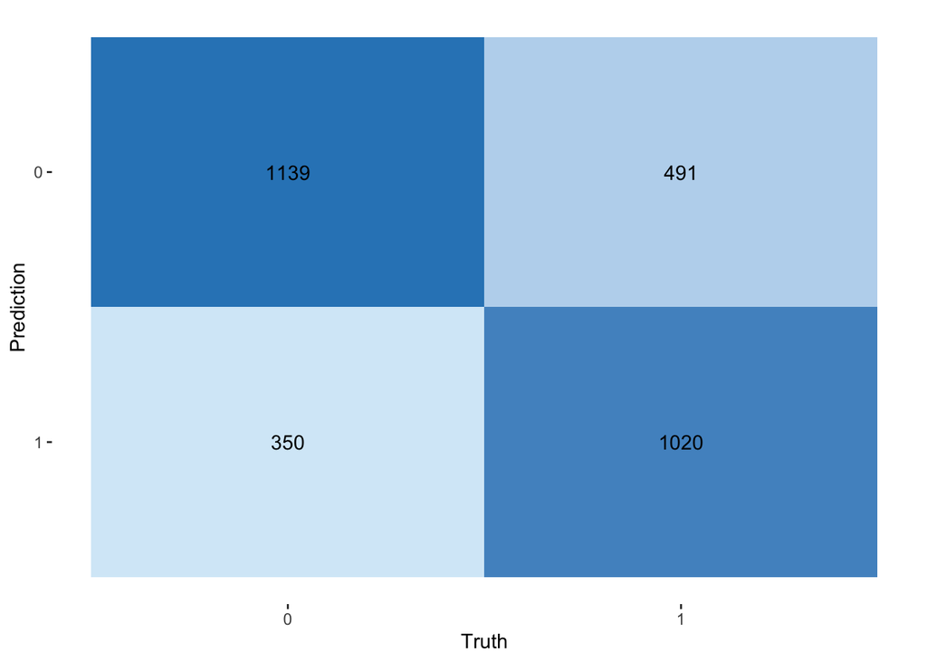

```r
results_tfidf[[2]]
```

#### Using Word Embeddings

```r
results_wv <- get_classifier(word_embeddings_df)
```

```
[1] "Accuracy (Number of correct classifications/Total number of cases): 76.83%"
```

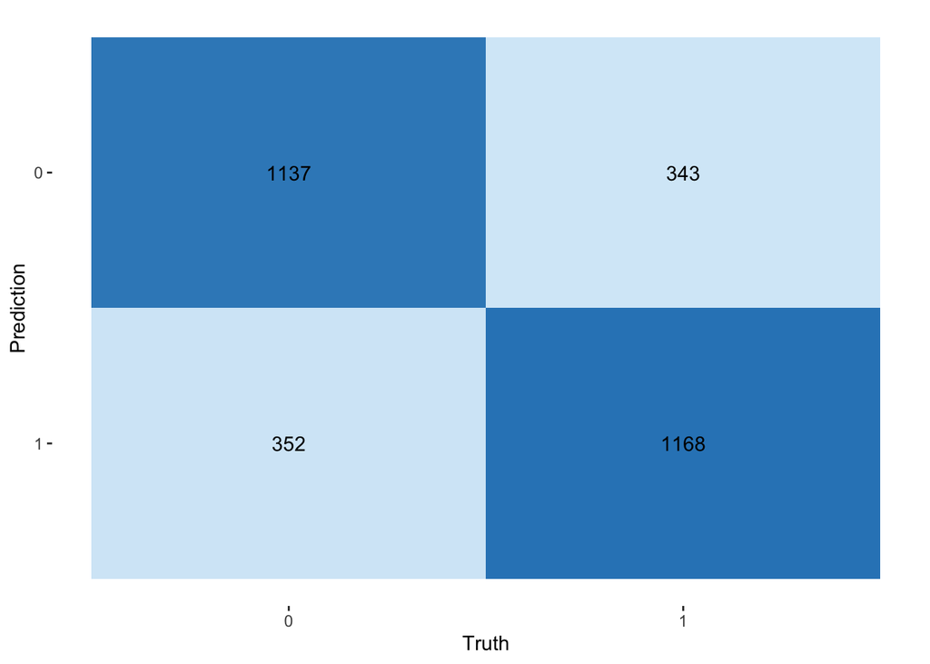

```r
results_wv[[2]]
```